# Linear Regression

Piyush Kumar

2022-05-31

**Loading the required libraries:**

```r
library(ggplot2)
library(gridExtra)
library(reshape)
library(ggcorrplot)
library(caret)
library(car)
library(lmtest)
```

**Reading data:**

```r
house = read.csv("USA_housing.csv")
head(house)
```

```
##   Avg..Area.Income Avg..Area.House.Age Avg..Area.Number.of.Rooms
## 1         79545.46            5.682861                  7.009188
## 2         79248.64            6.002900                  6.730821
## 3         61287.07            5.865890                  8.512727
## 4         63345.24            7.188236                  5.586729
## 5         59982.20            5.040555                  7.839388
## 6         80175.75            4.988408                  6.104512
##   Avg..Area.Number.of.Bedrooms Area.Population     Price
## 1                         4.09        23086.80 1059033.6
## 2                         3.09        40173.07 1505890.9
## 3                         5.13        36882.16 1058988.0
## 4                         3.26        34310.24 1260616.8
## 5                         4.23        26354.11  630943.5
## 6                         4.04        26748.43 1068138.1
##                                                Address
## 1 208 Michael Ferry Apt. 674\nLaurabury, NE 37010-5101
## 2 188 Johnson Views Suite 079\nLake Kathleen, CA 48958
## 3  9127 Elizabeth Stravenue\nDanieltown, WI 06482-3489
## 4                            USS Barnett\nFPO AP 44820
## 5                           USNS Raymond\nFPO AE 09386
## 6 06039 Jennifer Islands Apt. 443\nTracyport, KS 16077
```

# EDA:

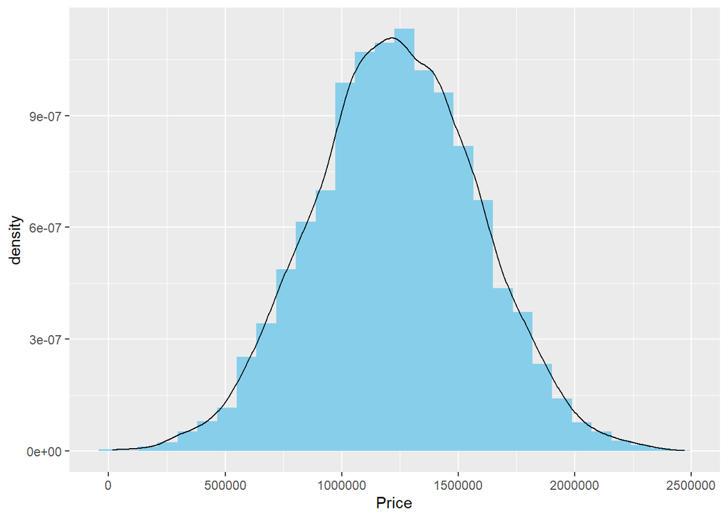

```r
# Checking Distribution of Response Variable

ggplot(house, aes(Price)) +
  geom_histogram(aes(y = ..density..), fill="skyblue") +
  geom_density()
```

Histogram displays an almost normal curve of the response variable. Hence we can say that Price of the house is somewhat normally distributed.

```r
# Analyzing the Statistics of the variables
summary(house)
```

```
##  Avg..Area.Income Avg..Area.House.Age Avg..Area.Number.of.Rooms
##  Min.   : 17797   Min.   :2.644       Min.   : 3.236
##  1st Qu.: 61481   1st Qu.:5.322       1st Qu.: 6.299
##  Median : 68804   Median :5.970       Median : 7.003
##  Mean   : 68583   Mean   :5.977       Mean   : 6.988
##  3rd Qu.: 75783   3rd Qu.:6.651       3rd Qu.: 7.666
##  Max.   :107702   Max.   :9.519       Max.   :10.760
##  Avg..Area.Number.of.Bedrooms Area.Population       Price
##  Min.   :2.000                Min.   :  172.6   Min.   :  15939
##  1st Qu.:3.140                1st Qu.:29403.9   1st Qu.: 997577
##  Median :4.050                Median :36199.4   Median :1232669
##  Mean   :3.981                Mean   :36163.5   Mean   :1232073
##  3rd Qu.:4.490                3rd Qu.:42861.3   3rd Qu.:1471210
##  Max.   :6.500                Max.   :69621.7   Max.   :2469066
##    Address
##  Length:5000
##  Class :character
##  Mode  :character
##
##
##
```

Looking at the summary statistics, one can easily observe that variables have means and medians very close to each other and that too lies somewhere to the middle of the range.

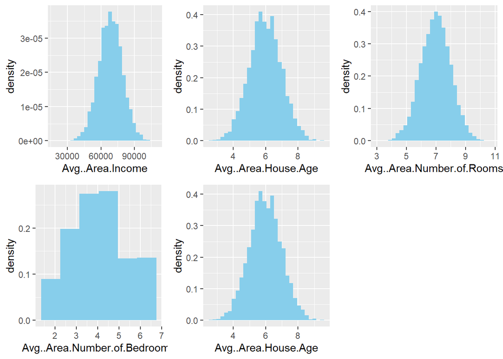

```r
# Plotting all the variables to see the distribution

g_Income= ggplot(house, aes(Avg..Area.Income)) +
  geom_histogram(aes(y = ..density..), fill="skyblue")

g_H_Age= ggplot(house, aes(Avg..Area.House.Age)) +
  geom_histogram(aes(y = ..density..), fill="skyblue")

g_H_Rooms= ggplot(house, aes(Avg..Area.Number.of.Rooms)) +
  geom_histogram(aes(y = ..density..), fill="skyblue")

g_H_BRooms= ggplot(house, aes(Avg..Area.Number.of.Bedrooms)) +
  geom_histogram(aes(y = ..density..),bins = 6, fill="skyblue")

g_Pop= ggplot(house, aes(Area.Population)) +
  geom_histogram(aes(y = ..density..), fill="skyblue")

grid.arrange(g_Income, g_H_Age, g_H_Rooms, g_H_BRooms, g_H_Age, ncol=3)
```

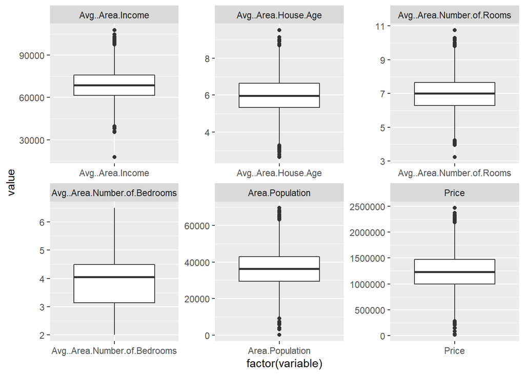

```r
# Plotting Boxplots to identify the outliers (if any)

melted_data = melt(house)
ggplot(melted_data, aes(factor(variable), value)) +
  geom_boxplot() +
  facet_wrap(~variable, scale="free")
```

All the variables seems to have potential outliers except “Number of Beds”.

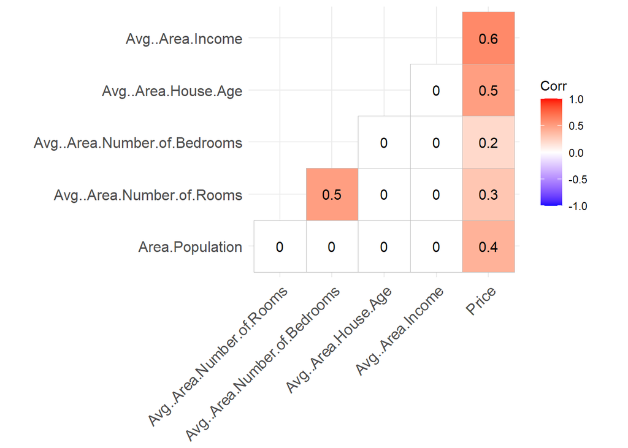

```r
# Visualizing the Correlation Matrix  to see relationship among variables
corr = round(cor(house[-7]),1)
house.mat = cor_pmat(house[-7])

ggcorrplot(corr, hc.order = TRUE, type = "lower", lab = TRUE)
```

From the above visualization, it is very clear that all the explanatory variables (i.e., all variables except price) has no relationship amongst each other. Only, correlation is observed between “No. of Bedrooms” and “No. of Rooms” which was expected. Also, all the explanatory variables have positive correlation and thus are correlated positively to the explained variable (i.e., Price).

# Training Regression Model

## Dividing the data into train and test subsets

```r
# The housing data is divided into 70:30 split of train and test. The 70:30 split is the most common and is mostly used during the training phase. 70% of the data is used for training, and the rest 30% is for testing how good we were able to learn the data behavior

index = unlist(createDataPartition(house$Price, p=0.70))
train = house[index,-7]
test = house[-index,-7]
```

## Building Model

```r
linear_model1 = lm( Price ~ ., data= train)
print(linear_model1)
```

```
##
## Call:
## lm(formula = Price ~ ., data = train)
##
## Coefficients:
##                  (Intercept)              Avg..Area.Income
##                   -2.634e+06                     2.155e+01
##          Avg..Area.House.Age     Avg..Area.Number.of.Rooms
##                    1.650e+05                     1.208e+05
## Avg..Area.Number.of.Bedrooms               Area.Population
##                    9.762e+02                     1.531e+01
```

## Applying Tests and checking the validity of the model

```r
summary(linear_model1)
```

```
##
## Call:
## lm(formula = Price ~ ., data = train)
##
## Residuals:
##     Min      1Q  Median      3Q     Max
## -335662  -69663     901   69022  357199
##
## Coefficients:
##                                Estimate Std. Error  t value Pr(>|t|)
## (Intercept)                  -2.634e+06  2.035e+04 -129.439   <2e-16 ***
## Avg..Area.Income              2.155e+01  1.597e-01  134.891   <2e-16 ***
## Avg..Area.House.Age           1.650e+05  1.722e+03   95.796   <2e-16 ***
## Avg..Area.Number.of.Rooms     1.208e+05  1.915e+03   63.070   <2e-16 ***
## Avg..Area.Number.of.Bedrooms  9.762e+02  1.557e+03    0.627    0.531
## Area.Population               1.531e+01  1.707e-01   89.705   <2e-16 ***
## ---
## Signif. codes:  0 '***' 0.001 '**' 0.01 '*' 0.05 '.' 0.1 ' ' 1
##
## Residual standard error: 100200 on 3494 degrees of freedom
## Multiple R-squared:  0.919,  Adjusted R-squared:  0.9189
## F-statistic:  7927 on 5 and 3494 DF,  p-value: < 2.2e-16
```

From the above summary table, it is very relevant that except “Avg..Area.Number.of.Bedrooms” all explanatory variables are highly significant even at very small level of significance. So, we can consider dropping the “Avg..Area.Number.of.Bedrooms” variables as it has good correlation with “Avg..Area.Number.of.Rooms” and comparatively less correlation with dependent variable (i.e., Price ).Also, the “Avg..Area.Number.of.Rooms” will account for the dropped variable as they must be related in general scenario.

Also, p-value corresponding to F-test for significance of overall model is almost zero which further rejects the null hypothesis (which we define as Ho : The Model is not significant).

## Fitting the model by dropping the “Avg..Area.Number.of.BedRooms” variable

```r
linear_model2 = lm( Price ~ . , data= train[-4])
print(linear_model2)
```

```
##
## Call:
## lm(formula = Price ~ ., data = train[-4])
##
## Coefficients:
##               (Intercept)           Avg..Area.Income
##                -2.635e+06                  2.155e+01
##       Avg..Area.House.Age  Avg..Area.Number.of.Rooms
##                 1.650e+05                  1.213e+05
##           Area.Population
##                 1.531e+01
```

## Applying Tests and checking the validity of the model

```r
summary(linear_model2)
```

```
##
## Call:
## lm(formula = Price ~ ., data = train[-4])
##
## Residuals:
##     Min      1Q  Median      3Q     Max
## -336468  -69576     677   68845  357275
##
## Coefficients:
##                             Estimate Std. Error t value Pr(>|t|)
## (Intercept)               -2.635e+06  2.034e+04 -129.51   <2e-16 ***
## Avg..Area.Income           2.155e+01  1.596e-01  135.02   <2e-16 ***
## Avg..Area.House.Age        1.650e+05  1.722e+03   95.81   <2e-16 ***
## Avg..Area.Number.of.Rooms  1.213e+05  1.687e+03   71.92   <2e-16 ***
## Area.Population            1.531e+01  1.707e-01   89.71   <2e-16 ***
## ---
## Signif. codes:  0 '***' 0.001 '**' 0.01 '*' 0.05 '.' 0.1 ' ' 1
##
## Residual standard error: 100200 on 3495 degrees of freedom
## Multiple R-squared:  0.919,  Adjusted R-squared:  0.9189
## F-statistic:  9910 on 4 and 3495 DF,  p-value: < 2.2e-16
```

Since, there is no difference between model1 and model2 in terms of R-squared and adjusted R-squared value, hence we can rely on model1 for prediction purpose. Both the models are highly significant.

Considering model1 and by all the above observations, we can say that our model is a good fit. We can proceed to further test our model.

# Checking the assumption of Linear Models

## 1) Normality of Random Errors

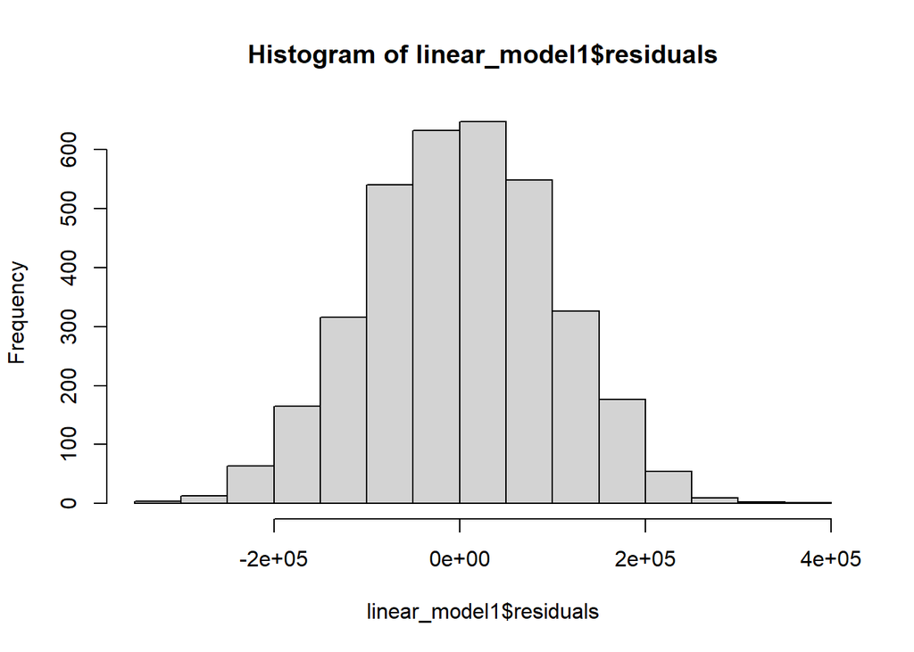

```r
hist(linear_model1$residuals)
```

The plotted histogram tells that the error variance follows normal distribution as it gives a bell-shaped curve. So, our first assumption holds. We can further consolidate our stated statement by plotting some graphs as follows and examining the independence of error terms:

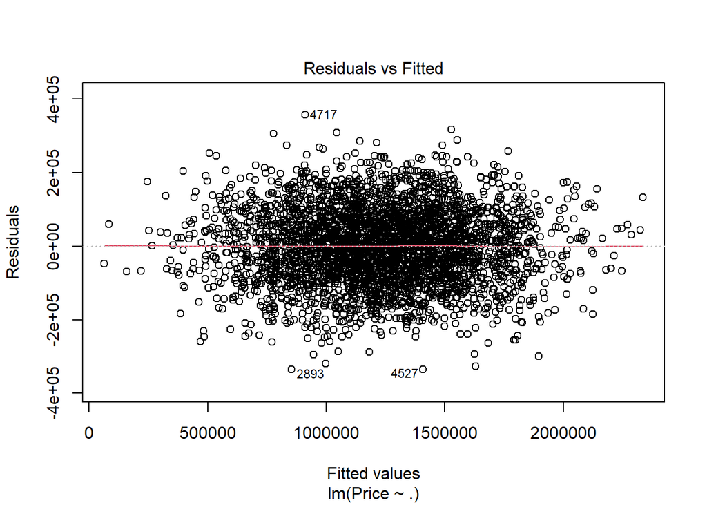

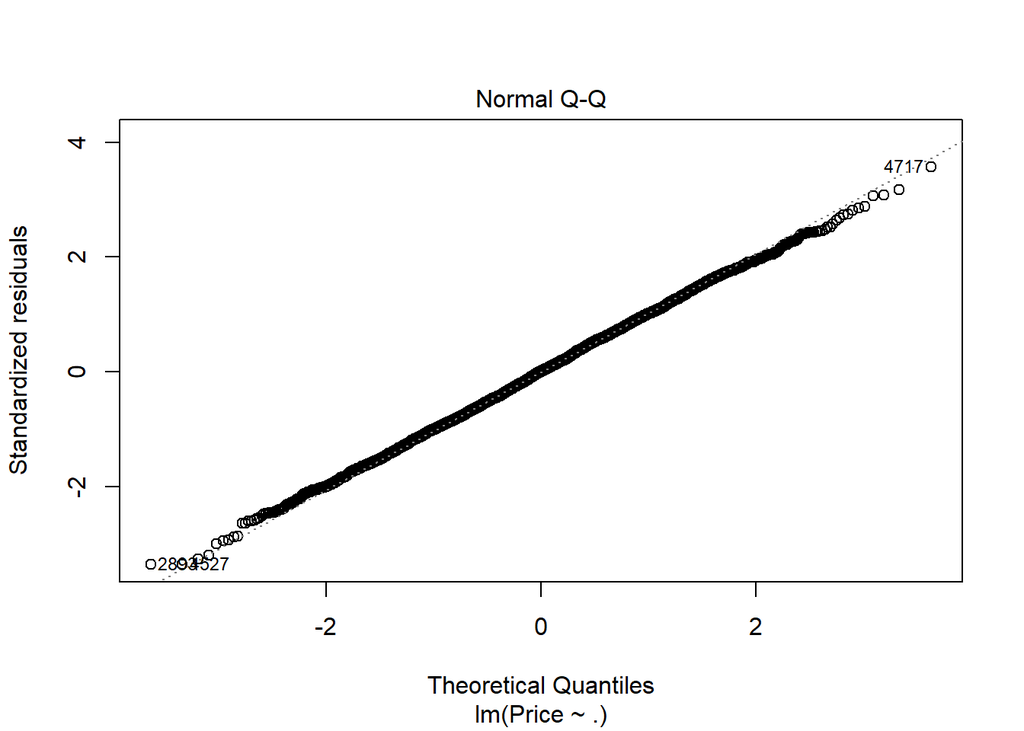

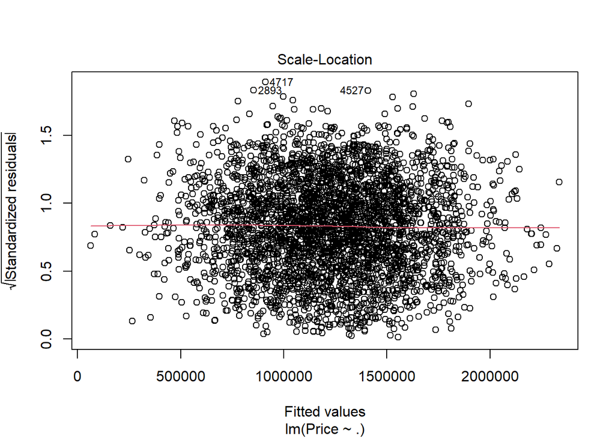

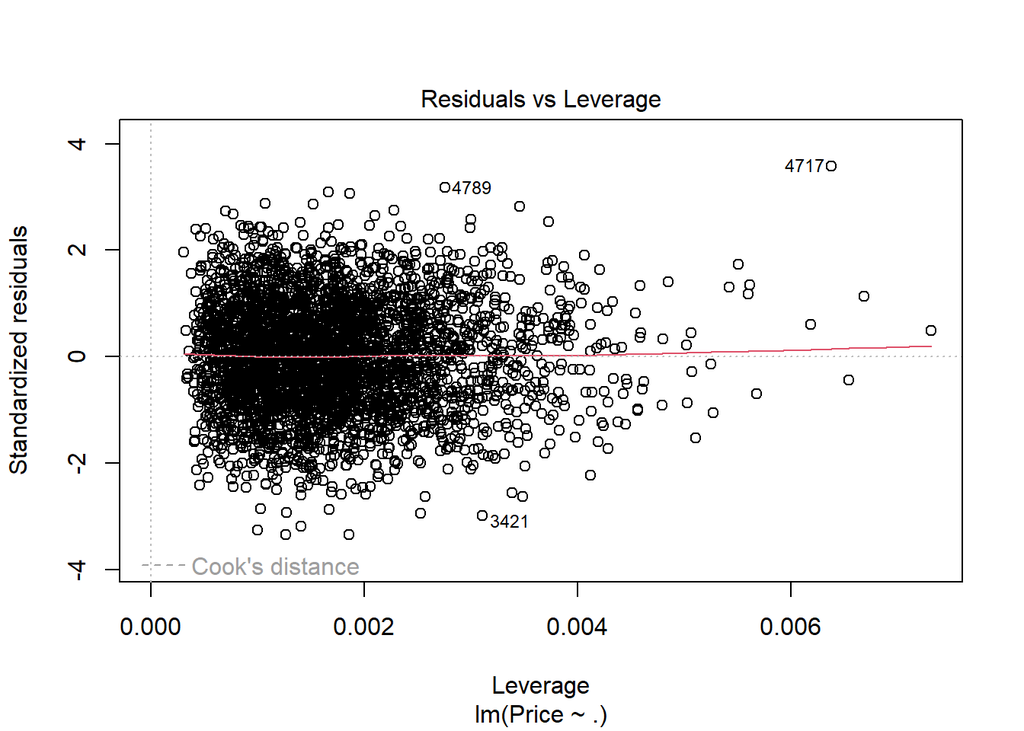

```r
plot(linear_model1)
```

## 2) Assumption of Homoscedasticity

This can confirmed by the above “residual vs Fitted” plot. One can easily observe that points are randomly distributed along the “zero residual line” and there’s no pattern or trend there. Thus, our model doesn’t seems to violate the assumption of homoscedasticity.

## 3) Assumption of no Multicollinearity

```r
# Calculating VIF for each variable to test the presence of multicollinearity in the model

car :: vif(linear_model1)
```

```
##             Avg..Area.Income          Avg..Area.House.Age
##                     1.001874                     1.001129
##    Avg..Area.Number.of.Rooms Avg..Area.Number.of.Bedrooms
##                     1.288105                     1.289359
##              Area.Population
##                     1.001589
```

All the variables have very low VIF and thus multicollinearity is not suspected.

## 4) Assumption of no AutoCorrelation

```r
# Durbin-Watson Test can be used to detect autocorrelation
dwtest(linear_model1)
```

```
##
##  Durbin-Watson test
##
## data:  linear_model1
## DW = 1.9837, p-value = 0.3151
## alternative hypothesis: true autocorrelation is greater than 0
```

The DW statistic is very close to 2 which shows that there is no autocorrelation in our fitted model.

# Running the model on the Test Dataset

```r
test$Predicted_Price= predict(linear_model1,test)
head(test[-c(1:5)])
```

```
##        Price Predicted_Price
## 3  1058988.0       1252028.6
## 5   630943.5        844321.6
## 6  1068138.1       1067167.8
## 9   798869.5        766083.9
## 11 1707045.7       1772379.6
## 22  929247.6       1079523.9
```

# Applying Chi-sqaure Test to test our model

```r
chisq.test(test[,7],test[,6])
```

```
##
##  Pearson's Chi-squared test
##
## data:  test[, 7] and test[, 6]
## X-squared = 2248500, df = 2247001, p-value = 0.2397
```

The above chi-square test reveals that our observed and predicted value are consistent with each other.

```r
actual= test$Price
preds= test$PreditedPrice
rss= sum((preds - actual) ^ 2)
tss= sum((actual - mean(actual)) ^ 2)
rsq= 1 - rss/tss
rsq
```

```
## [1] 1
```